# USCOTS workshop: first steps in Quarto and R

Nicholas Horton (nhorton@amherst.edu)

2023-05-23

This file provides an introduction to Quarto using a motivating example using a spreadsheet from a payroll register from Parsons Paper Company (Holyoke, Massachusetts) from the 1860’s that I’ve hand-transcribed.

Want to explore the page analyzed below? A Shiny app can be found here: https://r.amherst.edu/apps/nhorton/Parsons-Paper/

## Introduction to Quarto

[output not shown]

## Setup

I recommend having a setup chunk that loads the `tidyverse` and `mosaic` packages. From time to time you will need to add other packages here to add additional functionality. Note that the `include: false` option is specified so neither printing of code or output is displayed.

## Data input

```r
register <- readr::read_csv(
  "https://nhorton.people.amherst.edu/stat210/Parsons_page253.csv") |>
  mutate(daily_pay = total / number_days)
glimpse(register)
```

```
## Rows: 44
## Columns: 13
## $ lastname      <chr> "Johnson", "O'Brien", "Connor", "Kennedy", "Casey", "Gal…
## $ firstname     <chr> "William", "John W.", "William", "Martin", "James", "Tho…
## $ number_pounds <lgl> NA, NA, NA, NA, NA, NA, NA, NA, NA, NA, NA, NA, NA, NA, …
## $ number_reams  <lgl> NA, NA, NA, NA, NA, NA, NA, NA, NA, NA, NA, NA, NA, NA, …
## $ number_days   <dbl> 24.50, 21.50, 25.00, 23.00, 25.50, 25.00, 25.00, 27.00, …
## $ price1        <dbl> 16, 9, 16, 9, 12, 9, 12, 9, 12, 12, 12, 10, 7, 21, 15, 1…
## $ price2        <dbl> 6, 9, 6, 9, 0, 0, 0, 0, 0, 0, 0, 6, 6, 0, 0, 6, 9, 6, 0,…
## $ total         <dbl> 67.37, 34.95, 68.75, 37.38, 51.00, 37.50, 50.00, 40.50, …
## $ rent_or_board <dbl> NA, 4.67, 7.25, 0.00, 0.00, 0.00, 0.00, 0.00, 7.25, 0.00…
## $ balance_due   <dbl> 67.37, 30.28, 61.50, 37.38, 51.00, 37.50, 50.00, 40.50, …
## $ signature_x   <chr> "yes", "yes", "yes", "no", "no", "no", "no", "no", "no",…
## $ note          <chr> NA, "Brown and Flood?", NA, NA, NA, NA, NA, NA, NA, NA, …
## $ daily_pay     <dbl> 2.750, 1.626, 2.750, 1.625, 2.000, 1.500, 2.000, 1.500, …
```

We consider data from page 253 of the register.

## Data summaries + visualization

For those new to R, a number of useful functions are made available through the `mosaic` and `ggformula` packages for summary statistics, graphical displays, and modeling. (Those familiar with `ggplot2` can ignore these commands.)

The mosaic formula interface has several forms:

- GOAL(~ X, data = XX) univariate operation
- GOAL(Y ~ X, data = XX) bivariate operation
- A variety of GOAL’s have been implemented.

```r
mosaic::tally(~ signature_x, margins = TRUE, data = register)
```

```
## signature_x
##    no   yes Total
##    24    20    44
```

```r
mosaic::tally(~ signature_x, format = "prop", data = register)
```

```
## signature_x
##     no    yes
## 0.5455 0.4545
```

```r
mosaic::favstats(~ number_days, data = register)
```

```
##  min Q1 median   Q3 max  mean    sd  n missing
##  0.5 25     27 27.5  33 25.17 6.104 42       2
```

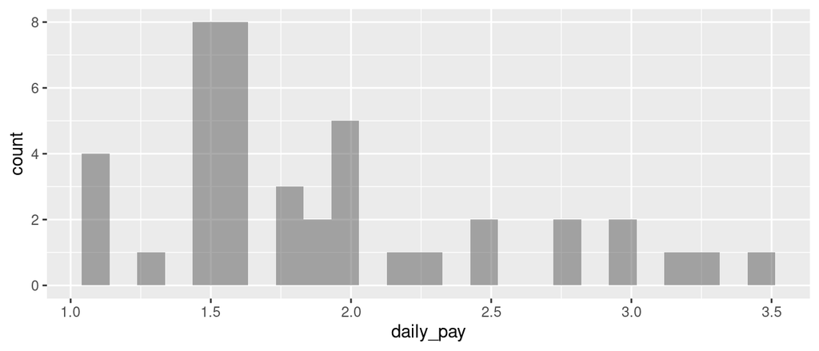

Histogram of daily pay (in 1860’s US dollars) for Parsons Paper Company employees

```r
gf_histogram( ~ daily_pay, data = register)
```

```r
#ggplot(register, aes(x = daily_pay)) +  # equivalent in ggplot
  #geom_histogram()
```

@fig-daily displays the histogram of daily pay per workday in 1860’s dollars.

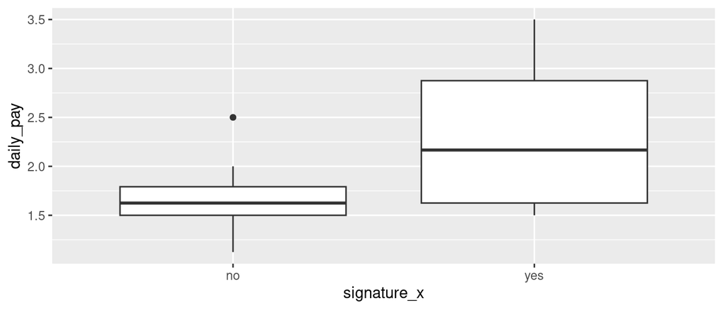

Daily salary per workday (in 1860’s US dollars) for Parsons Paper Company employees who couldn’t and who could sign their names

```r
gf_boxplot(daily_pay ~ signature_x, data = register)
```

```r
#ggplot(register, aes(x = signature_x, y = daily_pay)) +  # ggplot equivalent
  #geom_boxplot()
```

@tbl-pay displays the records for the employees with the lowest daily pay.

```r
lower_pay <- filter(register, daily_pay < 1.5)
lower_pay |>
  select(lastname, firstname, daily_pay, signature_x) |>
  kable()
```

| lastname | firstname | daily_pay | signature_x |
| --- | --- | --- | --- |
| Johnson | Chancy | 1.250 | no |
| Donlan | Mary | 1.125 | no |
| William | Kate | 1.125 | no |
| Moran | Kate | 1.125 | no |
| Baldwin | Kate | 1.125 | no |

## Modeling

Note that the `lm()` function uses a similar `Y ~ X` syntax. Here we explore how the daily pay relates to the daily rate variables (`price1` and `price2`).

```r
model <- lm(daily_pay ~ I(price1/6) + price2, data = register)
mosaic::msummary(model)
```

```
##             Estimate Std. Error t value Pr(>|t|)
## (Intercept)  0.02572    0.01693    1.52     0.14
## I(price1/6)  0.98346    0.00753  130.61  < 2e-16 ***
## price2       0.01356    0.00120   11.33  6.7e-14 ***
##
## Residual standard error: 0.0289 on 39 degrees of freedom
##   (2 observations deleted due to missingness)
## Multiple R-squared:  0.998,  Adjusted R-squared:  0.998
## F-statistic: 9.28e+03 on 2 and 39 DF,  p-value: <2e-16
```

@tbl-model provides the same information in a nice table.

If anyone knows anything about 1860’s currency (and the odd sixths) I’m all ears.

```r
kable(broom::tidy(model))
```

| term | estimate | std.error | statistic | p.value |
| --- | --- | --- | --- | --- |
| (Intercept) | 0.0257 | 0.0169 | 1.52 | 0.1367 |
| I(price1/6) | 0.9835 | 0.0075 | 130.61 | 0.0000 |
| price2 | 0.0136 | 0.0012 | 11.33 | 0.0000 |